# Esercizio 1

## Esercizio 1.1

Si vuole fare un’analisi dei seguenti dati, essi rappresentano il risultato di 60 osservazioni di una variabile che indica il tipo di danno alla salute presentato da 60 soggetti impiegati in un’azienda agricola e per i quali si sospetta l’esposizione a un pesticida.

I possibili valori assunti dalla variabile sono indicati con le lettere J= joint swelling; F = fatigue; B= back pain; M = muscle weakness; C= coughing; N = nose running/irritation, O =Other.

```r
pesticide <- c('O','O','J','O','J','O','F','O','F','O',
               'N','F','J','J','F','J','O','J','O','N',
               'C','O','F','O','F','N','N','B','B','O',
               'O','N','B','N','B','C','F','J','M','O',
               'O','F','O','O','J','J','J','O','O','B',
               'M','M','O','O','O','B','M','C','B','F')
```

- Si costruiscano le tabelle di frequenze assolute e relative della variabile categorica ‘pesticida’.
- Rappresentare graficamente la la variabile categorica ‘pesticida’.

### Si costruiscano le tabelle di frequenze assolute e relative della variabile categorica ‘pesticida’:

```r
(freq_ass=table(pesticide))

cat("\nvalori totali:", sum(freq_ass),"\n")

# oppure possiamo usare length(pesticide)
cat("\n")
(freq_rel=freq_ass/sum(freq_ass))
```

```
pesticide
 B  C  F  J  M  N  O
 7  3  9 10  4  6 21
```

```
valori totali: 60
```

```
pesticide
         B          C          F          J          M          N          O
0.11666667 0.05000000 0.15000000 0.16666667 0.06666667 0.10000000 0.35000000
```

### Rappresentare graficamente la la variabile categorica ‘pesticida’:

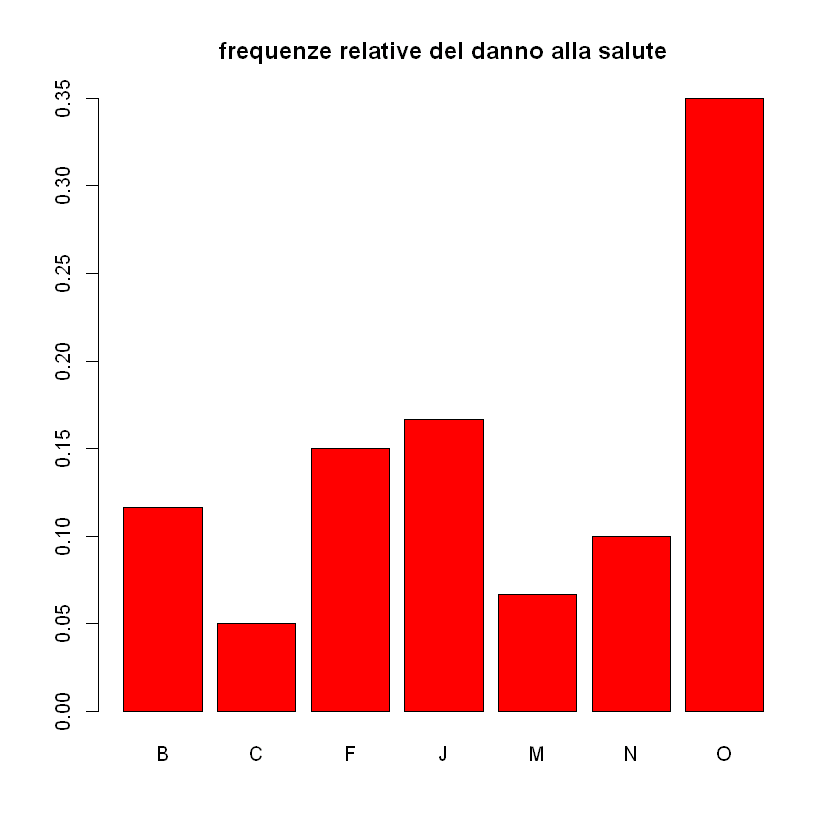

```r
barplot(freq_rel, main="frequenze relative del danno alla salute", col="red")
```

## Esercizio 1.2

Il vettore ‘patenti’ contiene l’indicazione della tipologia di patente che 30 individui intendono ottenere. A seguito dell’esame alcuni di essi vengono promossi (‘P’ nel vettore esame) e altri bocciati (‘B’).

Creare le tabelle di frequenza assoluta e relativa sia per la tipologia di patente che per l’esito dell’esame

Creare la tabella delle frequenza congiunte

Costruire il diagramma a torta e il diagramma a barre di entrambe le variabili ‘patente’ ed ‘esame’.

```r
patente <- c('B', 'A', 'B', 'D', 'A1', 'B', 'C',
             'B', 'B', 'B', 'B','A1', 'A', 'A', 'B',
             'B', 'C', 'B', 'B', 'B', 'D', 'A1', 'B',
             'A','B', 'A', 'C', 'D', 'B', 'B')

esame <- c('P', 'B', 'P', 'P', 'B', 'B', 'P', 'P',
           'P', 'B', 'P', 'P', 'B', 'B', 'B',
           'P', 'P', 'P', 'P', 'P', 'B', 'B',
           'P', 'B', 'P', 'B', 'P', 'P', 'P', 'P')
```

### Creare le tabelle di frequenza assoluta e relativa sia per la tipologia di patente che per l’esito dell’esame:

```r
freq_ass_patente <- table(patente)
freq_ass_patente
cat("\n")
freq_ass_esame <- table(esame)
freq_ass_esame

freq_rel_patente <- freq_ass_patente / sum(freq_ass_patente)
freq_rel_esame <- freq_ass_esame / sum(freq_ass_esame)


cat("\nfrequenza assoluta - per patente:\n\n")
freq_rel_patente
cat("\nfrequenza assoluta - per esito esame:\n\n")
freq_rel_esame
```

```
patente
 A A1  B  C  D
 5  3 16  3  3
```

```
esame
 B  P
11 19
```

```
frequenza assoluta - per patente:
```

```
patente
        A        A1         B         C         D
0.1666667 0.1000000 0.5333333 0.1000000 0.1000000
```

```
frequenza assoluta - per esito esame:
```

```
esame
        B         P
0.3666667 0.6333333
```

### Creare la tabella delle frequenza congiunte:

```r
cat("freq congiunta:\n\n")


freq_congiunta <- table(patente, esame)
freq_congiunta

cat("\n")

cat("freq congiunta relativa:\n\n")

freq_congiunta_rel <- freq_congiunta / sum(freq_congiunta)
freq_congiunta_rel
```

```
freq congiunta:
```

```
       esame
patente  B  P
     A   5  0
     A1  2  1
     B   3 13
     C   0  3
     D   1  2
```

```
freq congiunta relativa:
```

```
       esame
patente          B          P
     A  0.16666667 0.00000000
     A1 0.06666667 0.03333333
     B  0.10000000 0.43333333
     C  0.00000000 0.10000000
     D  0.03333333 0.06666667
```

### Costruire il diagramma a torta e il diagramma a barre di entrambe le variabili ‘patente’ ed ‘esame’:

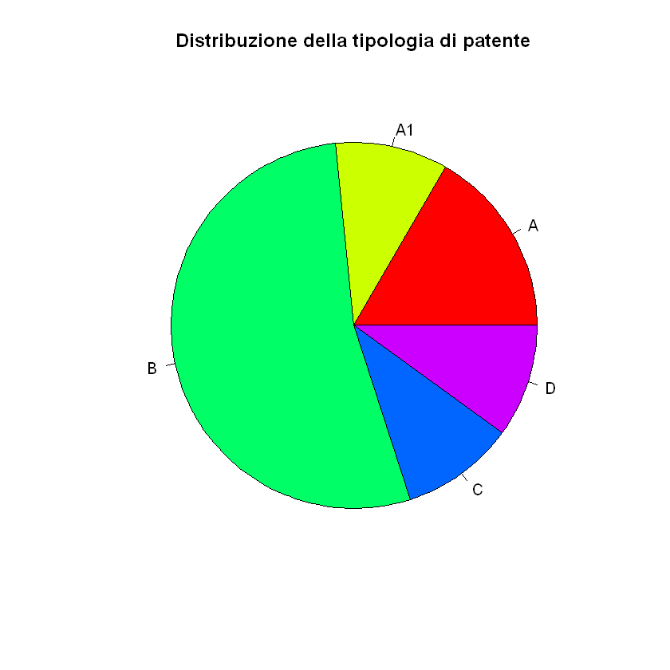

```r
pie(freq_rel_patente,
    main = "Distribuzione della tipologia di patente",
    col = rainbow(length(freq_rel_patente)))
```

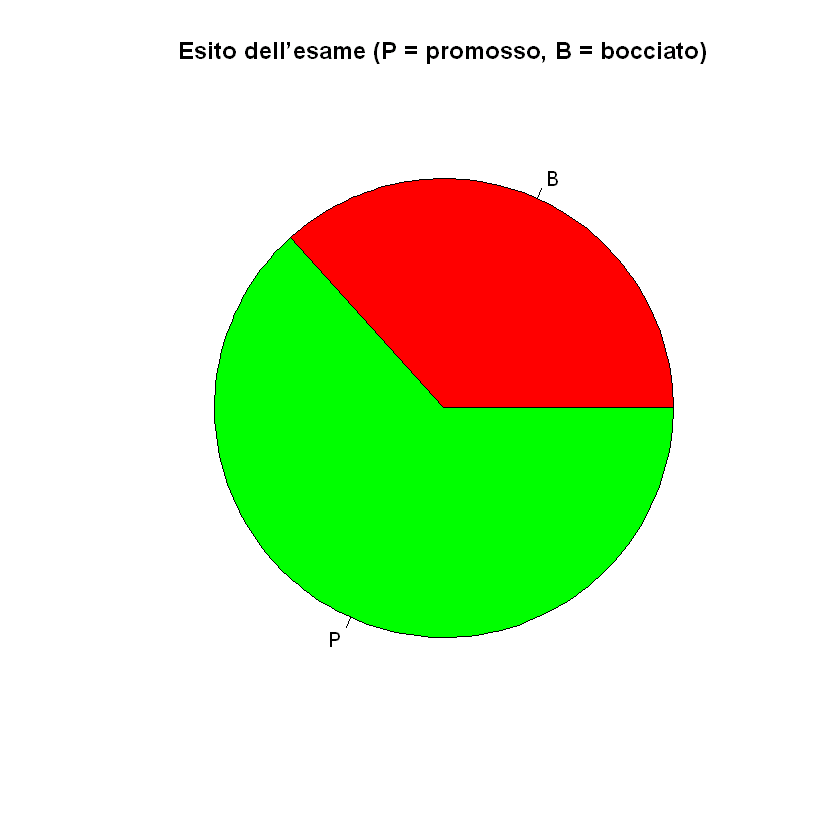

```r
pie(freq_rel_esame,
    main = "Esito dell’esame (P = promosso, B = bocciato)",
    col = c("red","green"))
```

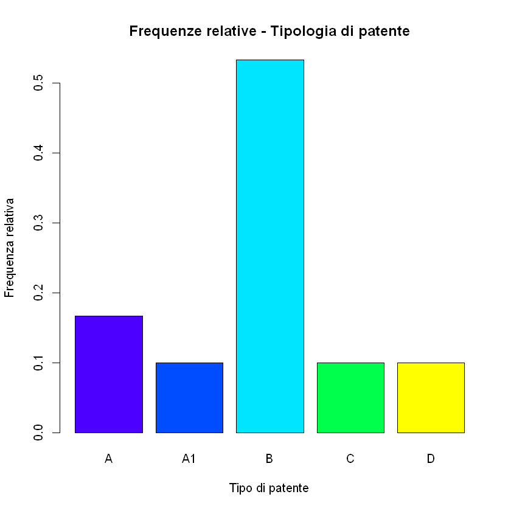

```r
barplot(freq_rel_patente,
        main = "Frequenze relative - Tipologia di patente",
        col = topo.colors(length(freq_rel_patente)),
        ylab = "Frequenza relativa",
        xlab = "Tipo di patente")
```

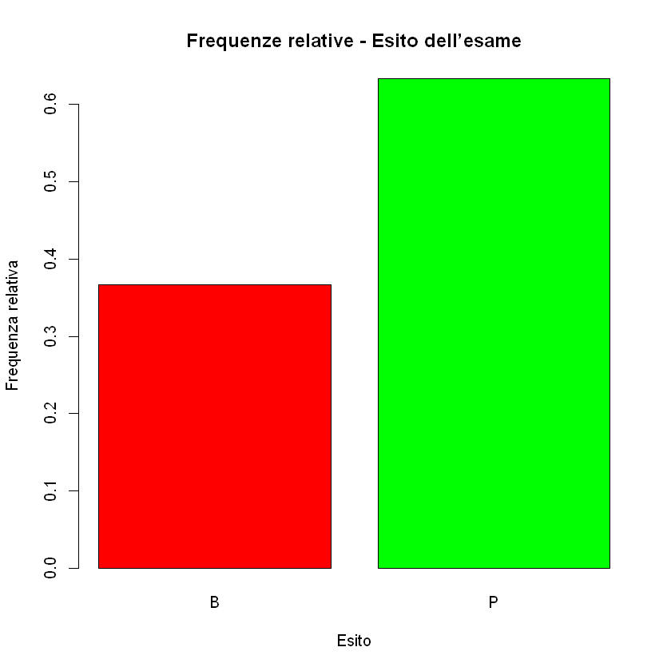

```r
barplot(freq_rel_esame,
        main = "Frequenze relative - Esito dell’esame",
        col = c("red","green"),
        ylab = "Frequenza relativa",
        xlab = "Esito")
```

### Bonus: frequenze congiunte:

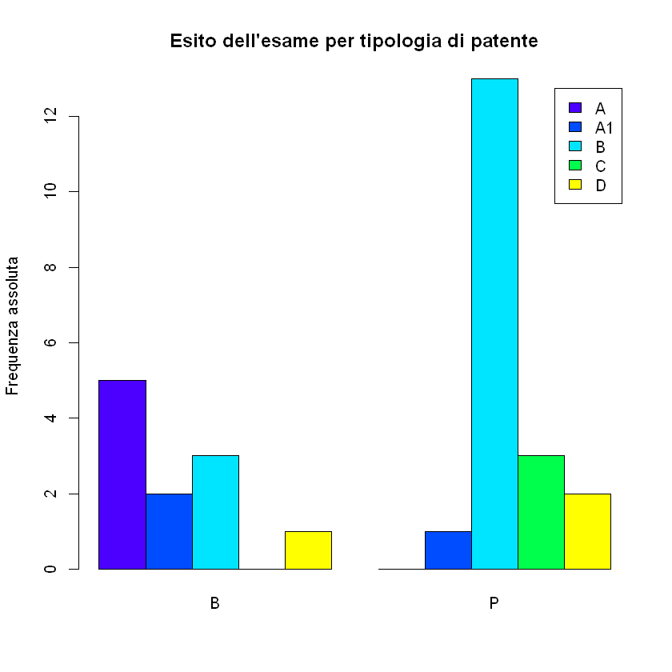

```r
barplot(freq_congiunta,
        beside = TRUE,
        col = topo.colors(length(freq_rel_patente)),
        legend = TRUE,
        main = "Esito dell'esame per tipologia di patente",
        ylab = "Frequenza assoluta")
```

## es 1.3

Si consideri il dataset ‘appendiceA.txt’, che contiene informazioni circa 312 pazienti di un ospedale.

Si costruiscano le tabelle di frequenze assolute e relative della variabile categorica ‘Sesso’.

Rappresentare graficamente la la variabile categorica ‘Sesso’.

### Si consideri il dataset ‘appendiceA.txt’:

```r
dati <- read.table("appendiceA.txt", header = TRUE)
```

### Si costruiscano le tabelle di frequenze assolute e relative della variabile categorica ‘Sesso’:

```r
cat("frequenza sesso")
freq_ass_sesso <- table(dati$Sesso)
freq_ass_sesso

cat("\nFrequenza sesso relativo")

freq_rel_sesso <- prop.table(freq_ass_sesso)
freq_rel_sesso

cat("\npercentuale sesso")
round(100 * freq_rel_sesso, 1)
```

```
frequenza sesso
```

```
  F   M
148 164
```

```
Frequenza sesso relativo
```

```
       F        M
0.474359 0.525641
```

```
percentuale sesso
```

```
   F    M
47.4 52.6
```

### Rappresentare graficamente la la variabile categorica ‘Sesso’:

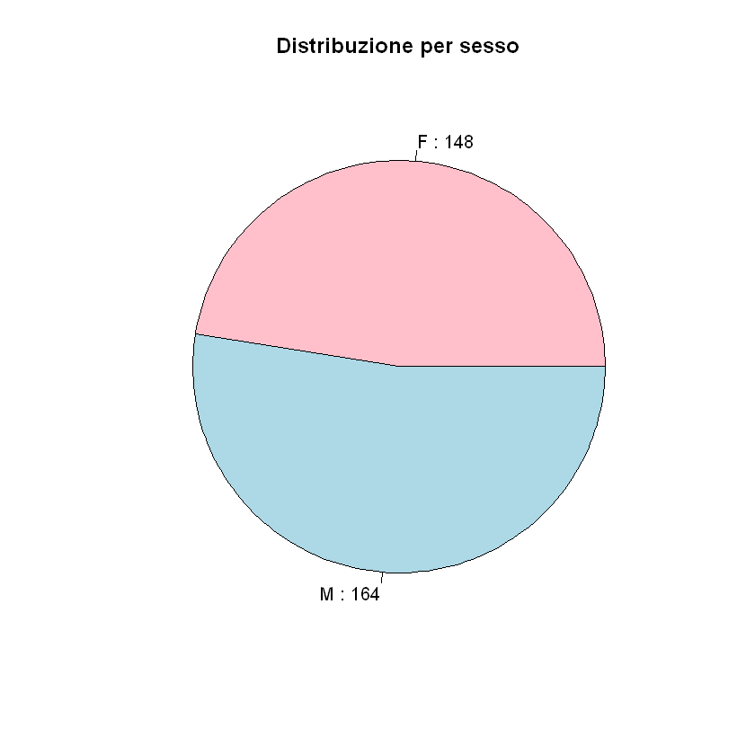

```r
pie(freq_ass_sesso,
    main = "Distribuzione per sesso",
    col = c("pink", "lightblue"),
    labels = paste(names(freq_ass_sesso), ":", freq_ass_sesso))
```

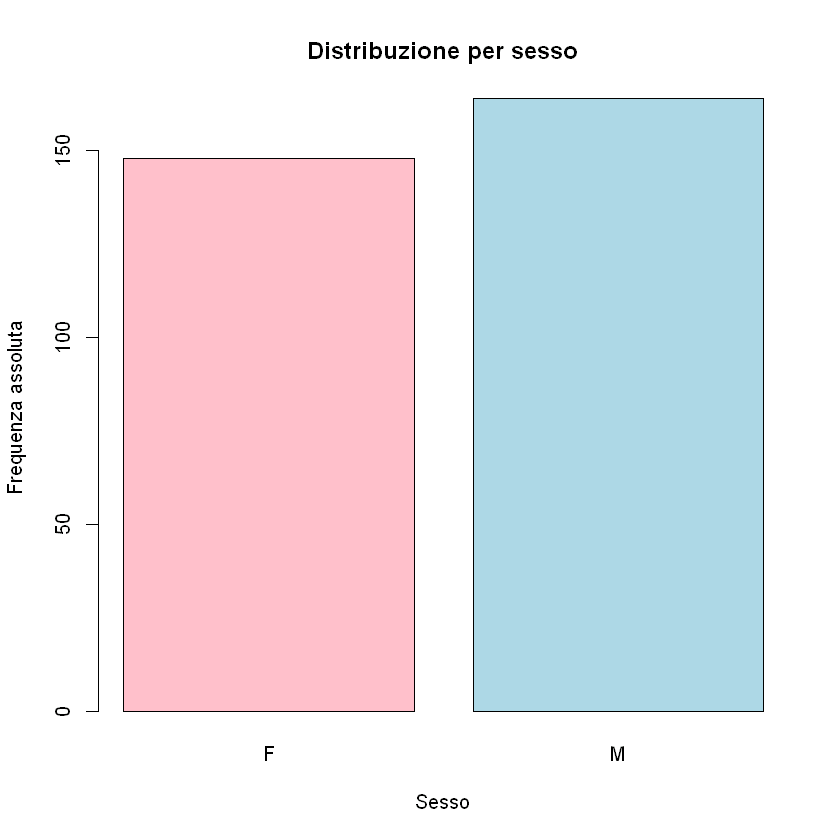

```r
barplot(freq_ass_sesso,
        main = "Distribuzione per sesso",
        col = c("pink", "lightblue"),
        ylab = "Frequenza assoluta",
        xlab = "Sesso")
```

## Es 1.4

Si consideri il dataset “painters” presente nel pacchetto MASS di R, che contiene informazioni su 54 pittori classici.

La quinta colonna del dataset contiene la variabile “School”, che indica il tipo di scuola che ogni pittore ha frequentato.

I possibili valori assunti dalla variabile “School” sono: “A”= Renaissance; “B”= Mannerist; “C”= Seicento; “D”= Venetian; “E”= Lombard; “F”= Sixteenth Century; “G”= Seventeenth Century and “H”= French.

Costruire la tabella delle frequenza assolute e relative.

Rappresentare graficamente la variabile.

### Si consideri il dataset “painters” presente nel pacchetto MASS di R, che contiene informazioni su 54 pittori classici:

```r
library(MASS)       # carica il pacchetto che contiene il dataset
data(painters)      # carica il dataset
head(painters)
str(painters)
```

A data.frame: 6 × 5

|  | Composition <int> | Drawing <int> | Colour <int> | Expression <int> | School <fct> |
| --- | --- | --- | --- | --- | --- |
| Da Udine | 10 | 8 | 16 | 3 | A |
| Da Vinci | 15 | 16 | 4 | 14 | A |
| Del Piombo | 8 | 13 | 16 | 7 | A |
| Del Sarto | 12 | 16 | 9 | 8 | A |
| Fr. Penni | 0 | 15 | 8 | 0 | A |
| Guilio Romano | 15 | 16 | 4 | 14 | A |

```
'data.frame':	54 obs. of  5 variables:
 $ Composition: int  10 15 8 12 0 15 8 15 4 17 ...
 $ Drawing    : int  8 16 13 16 15 16 17 16 12 18 ...
 $ Colour     : int  16 4 16 9 8 4 4 7 10 12 ...
 $ Expression : int  3 14 7 8 0 14 8 6 4 18 ...
 $ School     : Factor w/ 8 levels "A","B","C","D",..: 1 1 1 1 1 1 1 1 1 1 ...
```

### Costruire la tabella delle frequenza assolute e relative:

```r
freq_ass <- table(painters$School)
freq_ass
```

```
 A  B  C  D  E  F  G  H
10  6  6 10  7  4  7  4
```

```r
freq_rel <- prop.table(freq_ass)
freq_rel
```

```
         A          B          C          D          E          F          G
0.18518519 0.11111111 0.11111111 0.18518519 0.12962963 0.07407407 0.12962963
         H
0.07407407
```

### Rappresentare graficamente la variabile:

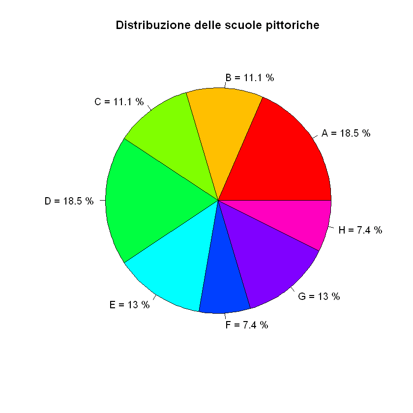

```r
pie(freq_rel,
    main = "Distribuzione delle scuole pittoriche",
    col = rainbow(length(freq_rel)),
    labels = paste(names(freq_rel), "=", round(100 * freq_rel, 1), "%"))
```

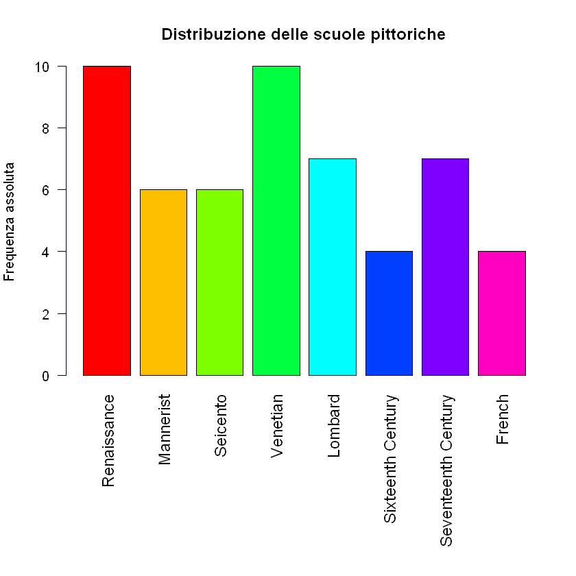

```r
etichette <- c("A"="Renaissance",
               "B"="Mannerist",
               "C"="Seicento",
               "D"="Venetian",
               "E"="Lombard",
               "F"="Sixteenth Century",
               "G"="Seventeenth Century",
               "H"="French")
par(mar = c(12, 4, 4, 2))
barplot(freq_ass,
        main = "Distribuzione delle scuole pittoriche",
        col = rainbow(length(freq_ass)),
        names.arg = etichette,
        las = 2,  # ruota le etichette per leggerle meglio
        cex.names = 1.2,
        ylab = "Frequenza assoluta")
```

# Es 2

# NUOVI ESERCIZI DI COMBINATORIA

## Esercizio (OpenIntro Statistics, David Diez)

In una classe con 24 studenti, 7 studenti indossano jeans, 4 indossano pantaloncini, 8 indossano gonne e gli altri indossano leggings. Se selezioniamo casualmente 3 studenti senza sostituzione, qual è la probabilità che uno degli studenti selezionati indossi dei leggings e gli altri due indossino dei jeans. Tieni presente che queste sono opzioni di abbigliamento che si escludono a vicenda. Utilizzare la funzione choose.

```r
# dati
J <- 7
P <- 4
G <- 8
L <- 24 - (J + P + G)  # = 5

# combinazioni favorevoli
favorevoli <- choose(L, 1) * choose(J, 2)

# combinazioni totali
totali <- choose(24, 3)

# probabilità
prob <- favorevoli / totali
prob
```

0.0518774703557312

## Esercizio

Una lotteria è costituita da 500 biglietti, di cui 6 vincenti. Si scelgono a caso 12 biglietti. Si vuole determinare la probabilità di A = “un biglietto è vincente”. Utilizzare la funzione choose.

```r
V<-6
E<-12 #estratti
Tot<- 500

favorevoli<-(choose(V,1)*choose(Tot - V, E - 1))

totali<-choose(Tot,E)

prob <- favorevoli/totali

prob
```

0.128754225947698

## Esercizio

Sia X una variabile casuale con supporto \(S_X=[−1,+∞)\) e funzione di densità \(f_X(x)=ke^{−x}\) , se \(x∈S_X\) , e nulla altrove, con k l’opportuna costante di normalizzazione. Si determini la costante k e si calcoli il valore atteso (Utilizzare la funzione integrate). Si calcolino la moda (Utilizzare la funzione optimize) e la mediana (Utilizzare la funzione uniroot). Rappresentare la funzione di densità e la funzione di ripartizione.

```r
#crea la funzione sopra descritta (semplificata a mano, in quanto l'integrale
# del tramai sopra è uguale a K=1/e)
k<-exp(-1)
f <- function(x){
     exp(-x)
}

(k=1/integrate (f, -1, Inf)$value)  #usiamo $value così passiamo il valore, non la funzione intera
```

0.367879441281134

```r
densita = function(x,k){ # crea la funzione semplificata
    k*f(x)
    }
# piccolo controllo per vedere che restituisca un numero e non un errore più lungo del codice scritto
densita (-1, k) # ci aspettiamo qualcosa tendente a 1
densita (0,k)  # ci aspettiamo un altro valore minonore di 1 e maggiore di 0
```

1.00000000029817

0.367879441281134

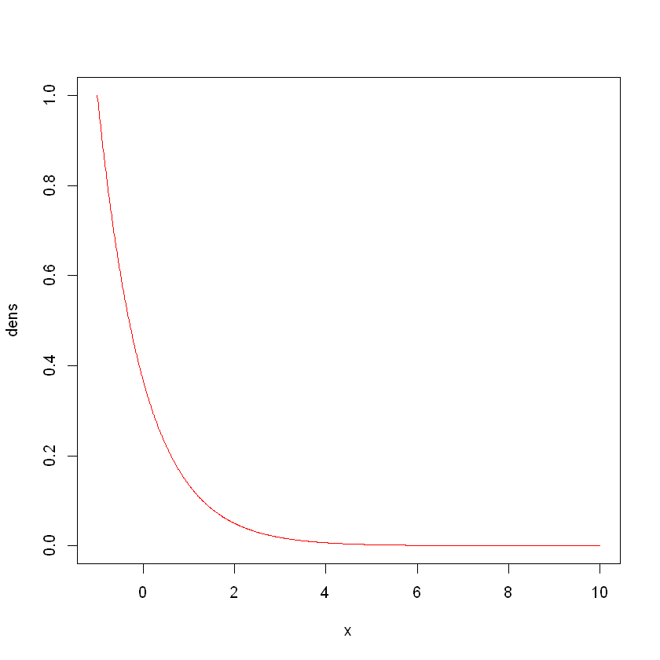

```r
x=seq(-1, 10, 0.01) # definisci cosa visualizzare nel grafico: da -1, a 10, con uno step di 0.01
                    # (buon compromesso per avere qualità decente
                    # e non tuonare il computer)

dens= densita(x, k)

plot(x, dens, type="l", col="red")  # ti fai il grafio così vedi se la funzione non implode
```

# Esercizio bonus:

Calcolare e plottare l'integrazione della funzione

\( \int_{-1}^{\inf} e^{-1}\)

0.367879441281134

```
-2.260192e-12 with absolute error < 1.7e-05
```

1. 0

2. 0.027047356109783

3. 0.0538255865296281

4. 0.0803373691048928

5. 0.106585355035928

6. 0.132572169143199

7. 0.158300410129774

8. 0.183772650841191

9. 0.208991438522747

10. 0.233959295074229

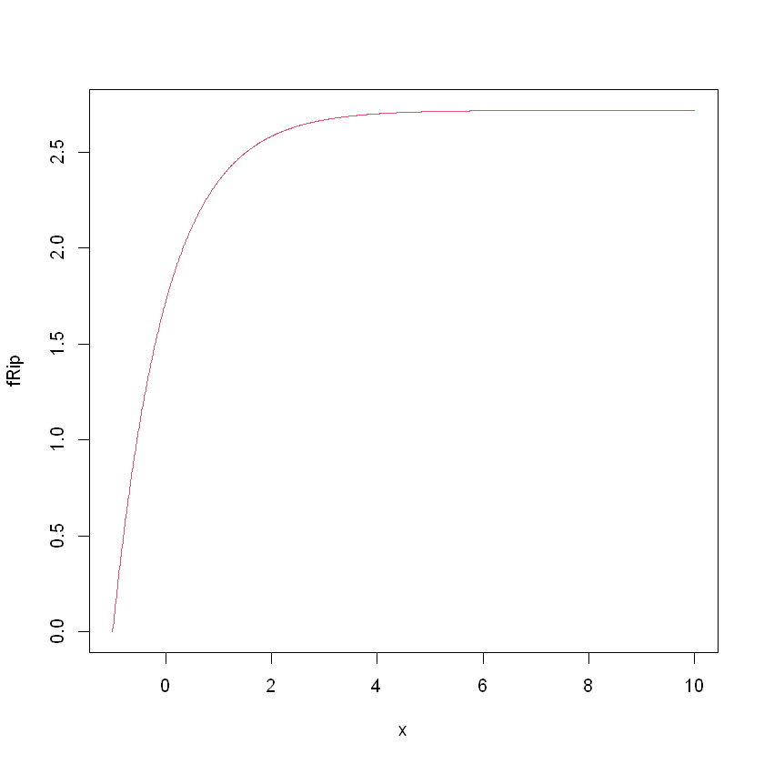

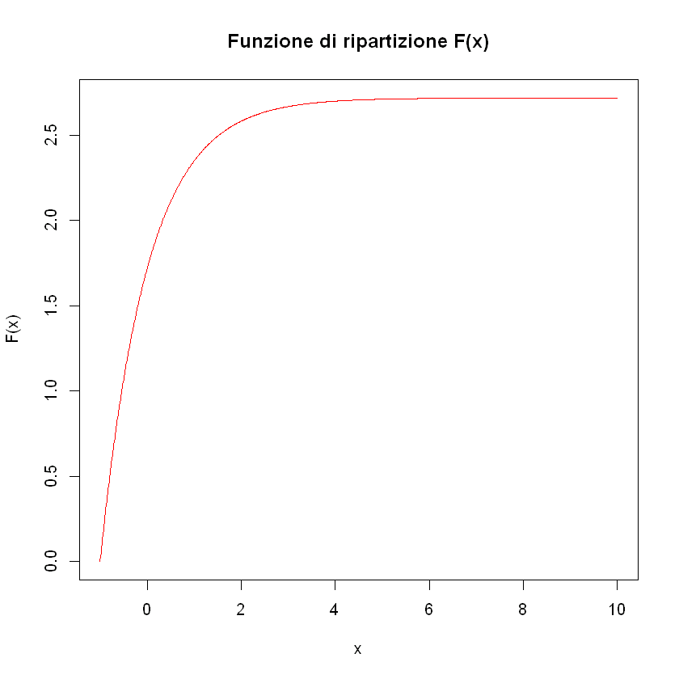

```r
#val atteso:

densita2=function(x){exp(-x)}#definisco funzione f
(k=1/integrate(f,-1,Inf)$value)#integro f da -1 a infinito

toInt=function(x){
    x*densita2(x)
    }

integrate(toInt,-1,Inf)

ripartizione=function(x){
    integrate(densita2,-1,x)$value
    }

fRip=NULL

for(i in 1:length(x)){
    fRip[i]=ripartizione(x[i])
    }

plot (x, fRip, type="l", col=2)

# secondo metodo:
fRip2=Vectorize(ripartizione, "x")
head(fRip2(x), 10) # head così non scrive sette milioni di righe

plot(x, fRip, type = "l", col = "red",
     main = "Funzione di ripartizione F(x)",
     xlab = "x", ylab = "F(x)")
```

```r
# calcolo della moda:
"moda:"
optimize(densita2, c(-1, 100),maximum =T)$maximum  #$maximum viene aggiunto per dare come ouput solo quel valore
# otimize1(densita2, c(-1, 100),maximum =T, k=k)

#calcolo della mediana:

densita2 <- function(x) {
  ifelse(x >= -1, exp(-(x + 1)), 0)
}
ripartizione <- function(x) {
  ifelse(x >= -1, 1 - exp(-(x + 1)), 0)
}
fRip2 <- Vectorize(ripartizione)
med <- function(x) fRip2(x) - 0.5
"mediana:"
uniroot(med, c(-1, 100))$root
```

'moda:'

-0.999952867536382

'mediana:'

-0.306842899094789

# Per casa:

Calcolare la varianza

# MODELLI

## Esercizio (Borra, Di Ciaccio. Statistica. Mc Graw Hill)

Un magazzino si rifornisce ogni settimana di un prodotto. La probabilità che nella settimana la domanda del prodotto superi lo stock del magazzino è pari a 0,013. Sia X il numero di volte durante l’anno (52 settimane) in cui la domanda ha superato lo stock di prodotto.

- Qual è la probabilità che durante l’anno non venga mai superato lo stock? Usare dbinom.
- Qual è la probabilità che nell’anno lo stock venga superato al massimo 2 volte? Usare dbinom o pbinom.
- Rappresentare la funzione di probabilità.
- Rappresentare la funzione di ripartizione.

### Probabilità che durante l’anno non venga mai superato lo stock

```r
n <- 52
p <- 0.013

P0 <- dbinom(0, size = n, prob = p)
cat("\n","Probabilità che durante l’anno non venga mai superato lo stock:", P0,"\n","\n")
```

```
 Probabilità che durante l’anno non venga mai superato lo stock: 0.5063979
```

### Probabilità che nell’anno lo stock venga superato al massimo 2 volte

```r
P_le_2 <- pbinom(2, size = n, prob = p)

cat("\n","Probabilità che nell’anno lo stock venga superato al massimo 2 volte:",P_le_2,"\n","\n")
```

```
 Probabilità che nell’anno lo stock venga superato al massimo 2 volte: 0.9697216
```

### Rappresentazione funzione di probabilità

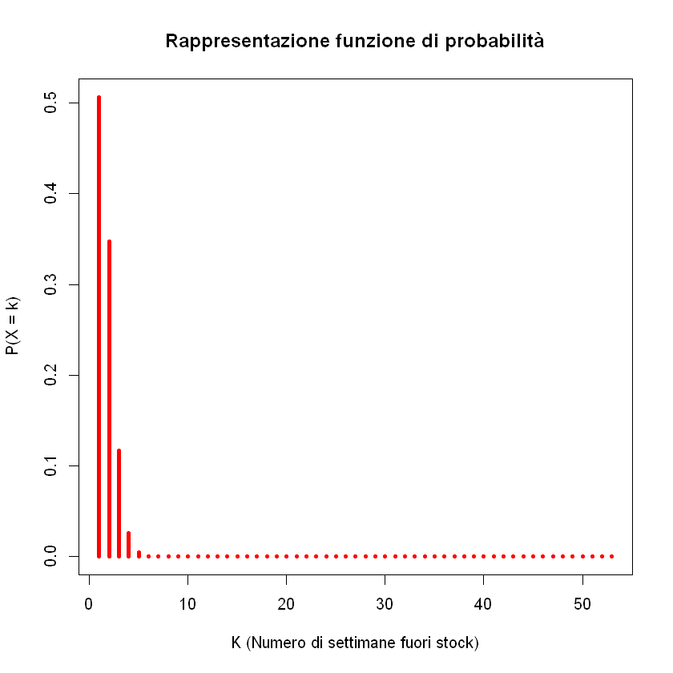

```r
n <- 52
p <- 0.013

k <- 0:52
pmf <- dbinom(k, size = n, prob = p)


plot(   pmf,
        xlab = "K (Numero di settimane fuori stock)",
        ylab = "P(X = k)",
        main = "Rappresentazione funzione di probabilità",
        col="red",
        type="h",
        lwd = 4
    )
```

### Rappresentare la funzione di ripartizione

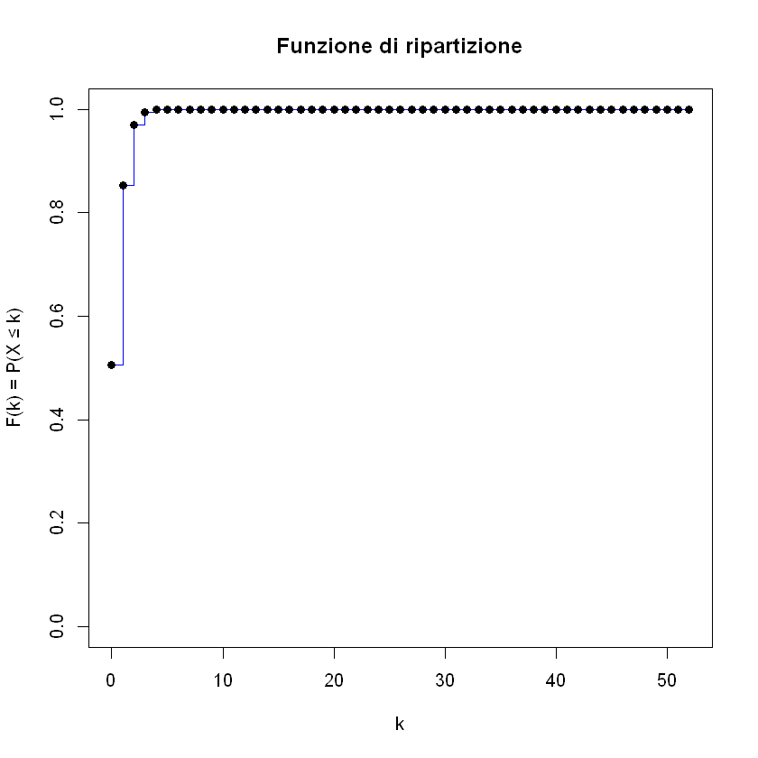

```r
n <- 52
p <- 0.013

k_all <- 0:52
pmf <- dbinom(k_all, size = n, prob = p)
cdf <- cumsum(pmf)

plot(k_all, cdf, type = "s",
     xlab = "k",
     ylab = "F(k) = P(X ≤ k)",
     main = "Funzione di ripartizione",
     ylim = c(0,1),
    col="blue")
points(k_all, cdf, pch = 16)
```

## Esercizio (Borra, Di Ciaccio. Statistica. Mc Graw Hill)

Il periodo di Vita in giorni delle particelle emesse da una sostanza radioattiva è una variabile di Poisson con media 3.8.

- Calcolare la probabilità che il peridodo di vita non sia superiore a 2 giorni. Usare ppois o dpois.

\( P(x \leq 2)=P(x=0)+P(x=1)+P(x=2) \)

```r
lambda <- 3.8
p<-ppois(2,lambda=lambda)
cat("Probabilità che il peridodo di vita non sia superiore a 2 giorni:", p)
```

```
Probabilità che il peridodo di vita non sia superiore a 2 giorni: 0.2688967
```

## Esercizio (OpenIntro Statistics, David Diez)

Una macchina produce uno speciale transistor, componente necessario nella costruzione dei computer. La macchina ha un tasso di errori del 2%, ovvero produce 2 pezzi difettosi ogni 100, in media. Il processo di produzione è tale che i vari pezzi possono essere considerati mutuamente indipendenti.

- Qual è la probabilità che il decimo transistor prodotto sia il primo a essere difettoso?

```r
p=2/100

cat(" probabilità che il decimo transistor prodotto sia il primo a essere difettoso:",p*((1-p)^9))
# si può anche usare:
# dgeom(9,p)  || si da il numero di fallimenti prima del primo successo
```

```
 probabilità che il decimo transistor prodotto sia il primo a essere difettoso: 0.01667496
```

## Esercizio (Borra, Di Ciaccio. Statistica. Mc Graw Hill)

Da una ricerca riguardante gli allevamenti di bestiame si è osservato che la distribuzione del Peso di bovini appartenenti alla classe 300-400 kg (estremi inclusi) può essere ben approssimata da una distribuzione uniforme continua.

- Calcolare la probabilità di osservare un bovino con un peso tra 310kg e 350kg. Utilizzare la funzione punif.
- Rappresentare la funzione di densità dell’uniforme. Utilizzare la funzione dunif.
- Generare in modo casuale 15 bovini con peso compreso tra 300 e 400 kg. Usare la funzione runif.

### Probabilità di osservare un bovino con un peso tra 310kg e 350kg

\(f(x)=\frac{1}{400-300}=\frac{1}{100}\)

\( P(310 \leq x \leq 350)=P(x\leq 350)-P(x\leq 310)=F(350)-F(310) \)

```r
a = 300
b = 400
punif(350, a, b) - punif(310, a, b)
```

0.4

### Rappresentare la funzione di densità dell’uniforme

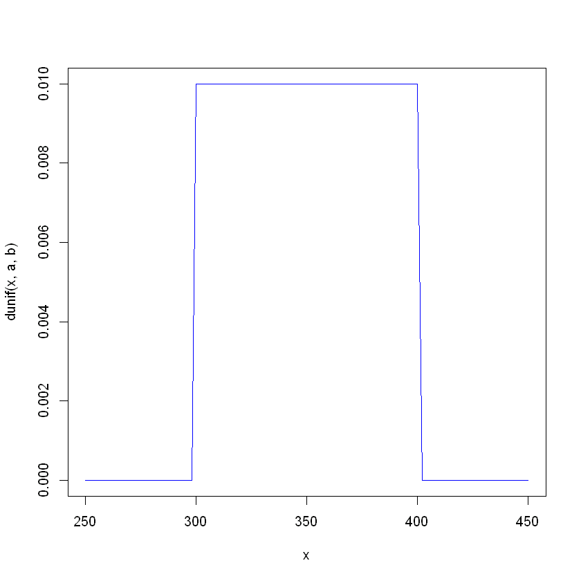

```r
curve(dunif(x, a, b),250,450,col="blue")
```

## Generare in modo casuale 15 bovini

```r
set.seed(1011) #seme per non aver numeri diversi
runif(15,a,b)
```

1. 380.661476030946

2. 307.04243928194

3. 327.411410864443

4. 373.531162086874

5. 323.670887900516

6. 385.078246193007

7. 375.695959432051

8. 313.01041841507

9. 389.086867799051

10. 358.521142671816

11. 360.505041107535

12. 383.77921434585

13. 350.624389993027

14. 376.218020939268

15. 334.674977092072

## Esercizio

Il tempo che mediamente trascorre tra l’apertura di uno sportello pubblico e l’arrivo del primo utente è di 4 minuti. Si proponga un modello probabilistico ragionevole per la variabile casuale X che descrive il tempo tra l’apertura dello sportello e l’arrivo del primo utente. Si determini la probabilità che il tempo d’attesa del primo utente superi i 10 minuti. Utilizzare la funzione pexp.

```r
media=4
lambda=1/media
1-pexp(10,rate=lambda)
```

0.0820849986238988

## Esercizio (Mecatti, Statistica di base, Mc Graw Hill)

Il voto ottenuto al appello d’esame di Statistica segue una distribuzione normale con media \(μ=23\) e varianza \(σ^2=9\).

- Determinare la probabilità di prendere un voto maggiore di 21 e inferiore a 25. Utilizzare la funzione pnorm.
- Determinare la probabilità di prendere un voto maggiore di 28. Utilizzare la funzione pnorm.
- Trovare il voto corrispondente al 95%. Utilizzare la funzione qnorm.
- Rappresentare la densità di probabilità. Utilizzare la funzione dnorm.

### Probabilità di prendere un voto maggiore di 21 e inferiore a 25:

\( \Phi= \) funzione di distribuzione della normale (pnorm)

\( P(21 \leq x \leq 25) = \Phi(25)-\Phi(21) \)

0.495014924906154

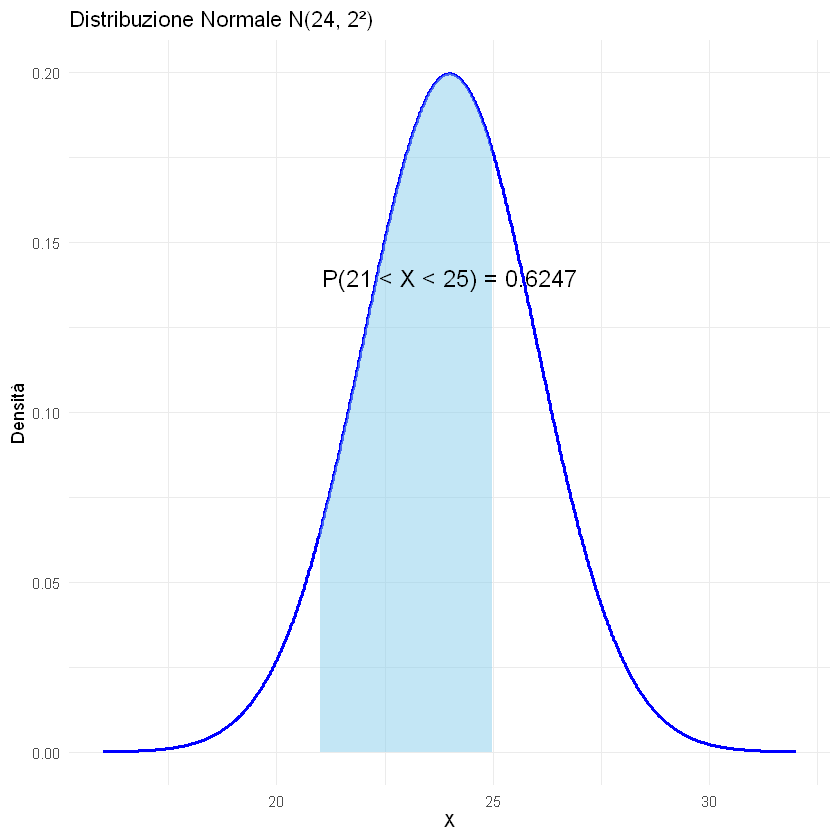

```r
media= 23
varianza = 9
pnorm(25, mean = media, sd =sqrt(varianza))-pnorm(21 , mean = media, sd= sqrt(varianza))
# install.packages("ggplot2") # se non lo hai già
library(ggplot2)

# Parametri
media <- 24
varianza <- 4
sd <- sqrt(varianza)

# Calcolo della probabilità
p_area <- pnorm(25, mean = media, sd = sd) - pnorm(21, mean = media, sd = sd)

# Costruzione dati per la curva
x <- seq(media - 4*sd, media + 4*sd, length.out = 1000)
y <- dnorm(x, mean = media, sd = sd)
df <- data.frame(x, y)

# Grafico con area evidenziata e testo della probabilità
ggplot(df, aes(x, y)) +
  geom_line(color = "blue", linewidth = 1) +
  geom_area(
    data = subset(df, x >= 21 & x <= 25),
    aes(y = y),
    fill = "skyblue",
    alpha = 0.5
  ) +
  annotate(
    "text",
    x = media, y = max(y) * 0.7,       # posizione del testo
    label = paste0("P(21 < X < 25) = ", round(p_area, 4)),
    size = 5, color = "black"
  ) +
  labs(
    title = "Distribuzione Normale N(24, 2²)",
    x = "X",
    y = "Densità"
  ) +
  theme_minimal()
```

### Voto maggiore di 28:

\( P(x>28)=1-P(\leq 28)=1-\Phi(28) \)

```r
1- pnorm(28,mean=media,sd=sqrt(varianza))
```

0.0227501319481792

### Trovare il voto corrispondente al 95%:

\( P(X>x_{0.95})=0.05 \)

```r
qnorm(0.95,mean=media,sd=sqrt(varianza))
```

[output not shown]

### Rappresentare la densità di probabilità:

[figure not shown]

```r
curve(dnorm(x,mean=media,sd=sqrt(varianza)),media-3*sqrt(varianza),media+3*sqrt(varianza),col="blue",ylab="densità")
```

## Statisiche campionarie

Questi esercizi sono stati tratti dal libro “Laboratorio di Statistica con R (Ieva, Masci e Paganoni)” e da “OpenIntro Statistics, (David Diez)”.

### Esercizio 1

Supponiamo che la percentuale di americani che sostengono l’espansione dell’energia solare sia p=0.88, il parametro di interesse. Dopo aver estratto un campione di 1000 americani dalla popolazione vogliamo studiare l’andamento della proporzione campionaria.

- Crea un insieme di 250 milioni di risposte, di cui l’88% sono “supporto” e il restante sono “non supporto”.
- Estrai dalla popolazione 1000 risposte senza sostituzione. Utilizza la funzione sample.
- Calcolare la proporzione campionaria.
- Ripeti l’operazione 1000 volte e rappresenta tramite un grafico il risultato della simulazione (usare plot), aggiungi sul grafico anche la vera proporzione p=0.88 (usare abline). Cosa puoi concludere?
- Cosa si può dire sulla distribuzione campionaria della proporzione campionaria p¯ (x¯n )?
- Calcolare la media della proporzione campionaria e la deviazione standard.
- Rappresentare tramite un istogramma il risultato della simulazione e aggiungere sul grafico la curva che approssima la distribuzione.

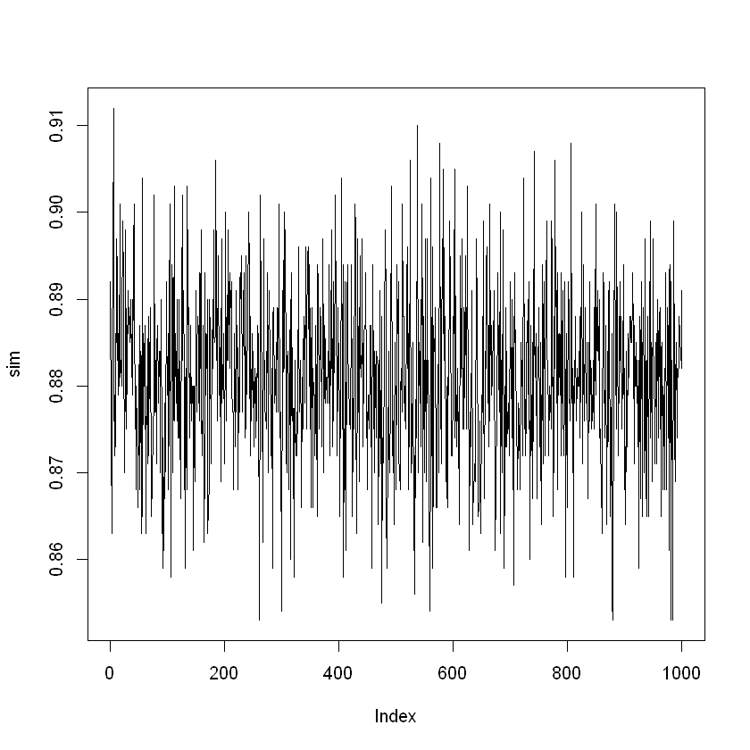

0.880915

0.000102636411411412

0.0001056

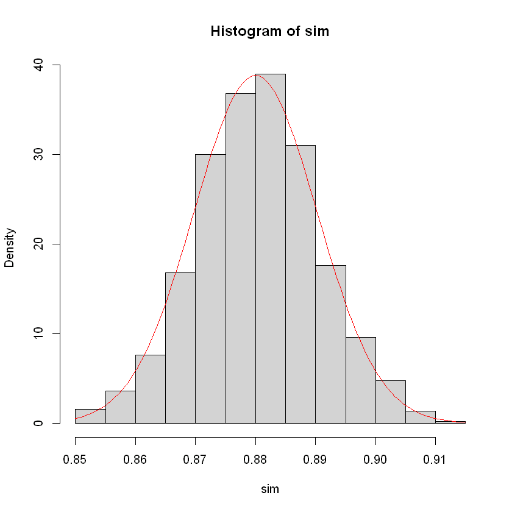

```r
N <- 250000000 # 250.000.000
n <- 1000 # numerosità campione
p=0.88

pop = c(rep("supporto",N*p), rep("non supporto",N*(1-p))) # calcolo

campione = sample(pop,n) # di default è senza ripetizione
                         # se vogliamo il replace usiamo "replace = T"

# phat = sum(campione == "supporto")/n  # calcoliamo la proporzione campionaria

sim = c()
for (i in 1:1000){
    campione = sample(pop,n)
    phat = sum(campione == "supporto")/n  # calcoliamo la proporzione campionaria
    sim = append(sim, phat)
}
# simulazione per 1000 lanci

plot(sim, type="l")

hist(sim, prob="T")
curve(dnorm(x,mean=p,sd=sqrt(p*(1-p)/n)),add=T,col="red")

mean(sim) # media campionaria
var(sim) # varianza campionaria
p*(1-p)/n
```

### Esercizio 2

Si vogliono simulare 500 lanci di una moneta truccata in cui la probabilità di ottenere testa è pari a 0.7, e si intende studiare come la proporzione di casi in cui si ottiene testa cambi all’aumentare del numero di lanci.

- Simulare 500 lanci della moneta truccata in cui la probabilità di ottenere testa è pari a 0.7. Utilizzare la funzione rbinom.
- Si calcoli la successione di valori della media campionaria (Calcolare la proporzione di casi in cui si ottiene testa) ottenuta a partire da 2 osservazioni fino a 500 (utilizzare la funzione cumsum).
- Rappresentare su un grafico tali successioni, confrontandole con il valore atteso secondo la teoria.

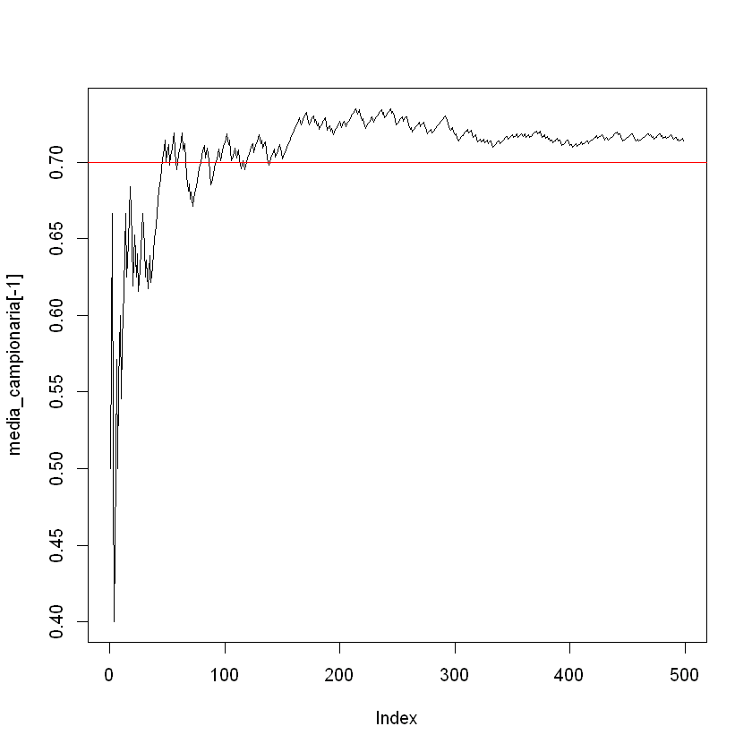

```r
n_l = 500 # numero lanci
p=0.7 # probabilità successo
set.seed(123)
lanci_moneta = rbinom(n_l, 1 ,p) # simulazione di 500 lanci (0 crocie, 1 testa)

media_campionaria = cumsum(lanci_moneta)/(1:n_l)  # simuliamo senza la prima prova

plot(media_campionaria[-1], type="l")
abline(h=p,col="red")
```

### Esercizio 3

Si studi l’andamento della legge della somma e della media campionaria di n variabili aleatorie indipendenti, ciascuna con legge Uniforme nell’intervallo [0,1] , al variare di n (n>50 ).

- Si simulino N=1000 realizzazioni della media e della somma di n=50,100,200,500 v.a. Uniforme nell’intervallo [0,1] .
- Studiare la gaussianità della distribuzione delle medie con un istogramma e aggiungere la densità delle v.a. gaussiane relative all’approssimazione normale per le varie numerosità campionarie.
- Studiare la gaussianità della distribuzione delle somme con un istogramma e aggiungere la densità delle v.a. gaussiane relative all’approssimazione normale per le varie numerosità campionarie.
- Studiare la gaussianità della distribuzione delle somme con il QQ plot.

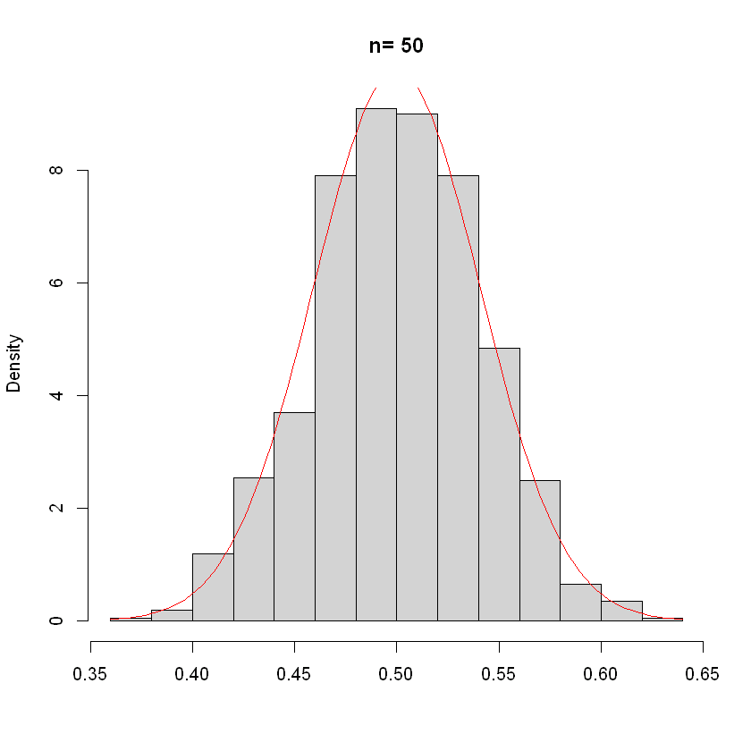

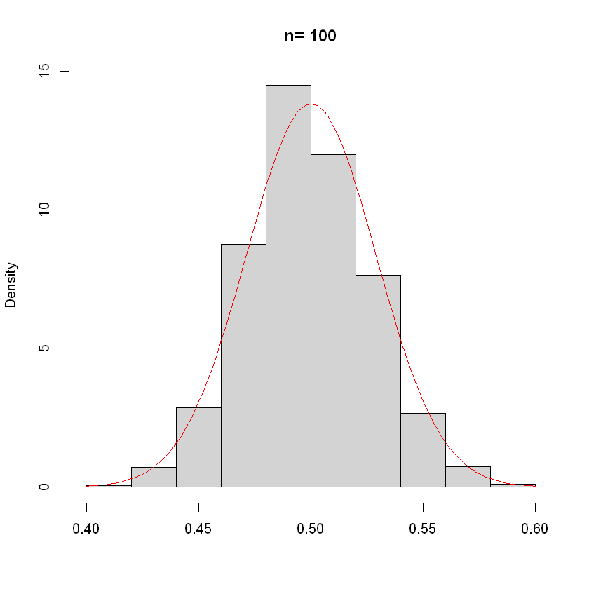

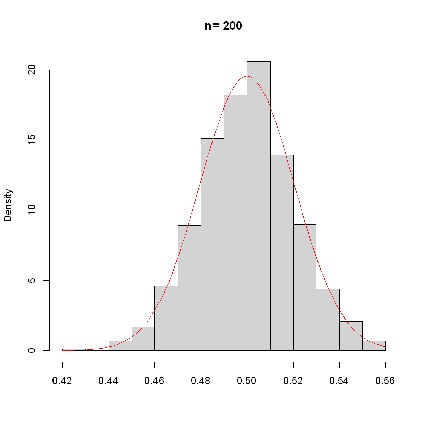

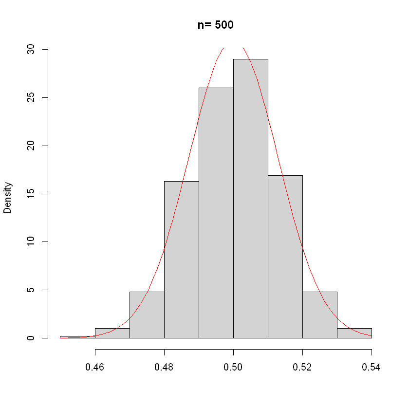

```r
n = c(50,100,200,500)
nrep=1000

media = matrix(0, nrow = nrep, ncol = length(n))

somma = matrix(0, nrep, ncol=length(n))

for (j in 1:length(n)){
    for(i in 1:nrep){
        x=runif(n[j],0,1)  # gnero n[j] elementi da un'uniforme 0,1
        media[i,j] = mean(x)  # popolo le matrici
        somma[i,j] = sum(x)

        }
    }

# studiare gaussianità delle medie


for (j in 1:length(n)){
    hist(media[,j],prob=T,main = paste("n=",n[j]),xlab="")
    curve(dnorm(x,0.5,sqrt(1/(12*n[j]))),add=T,col="red")
    }
```

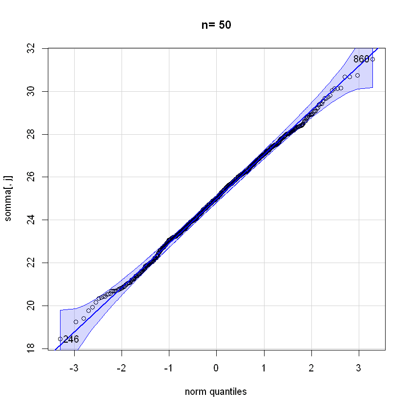

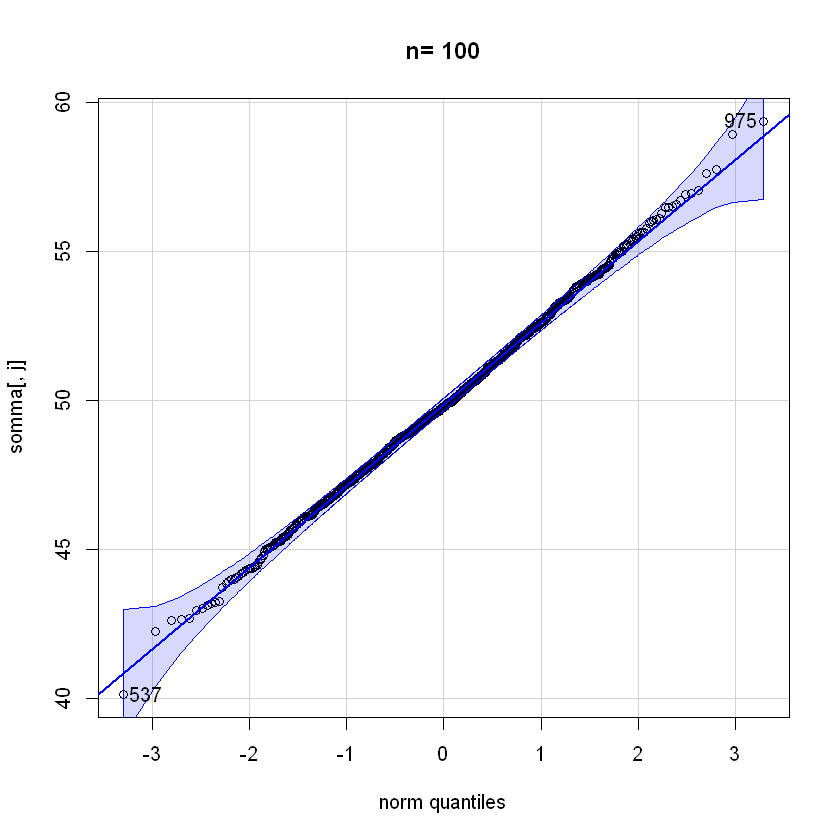

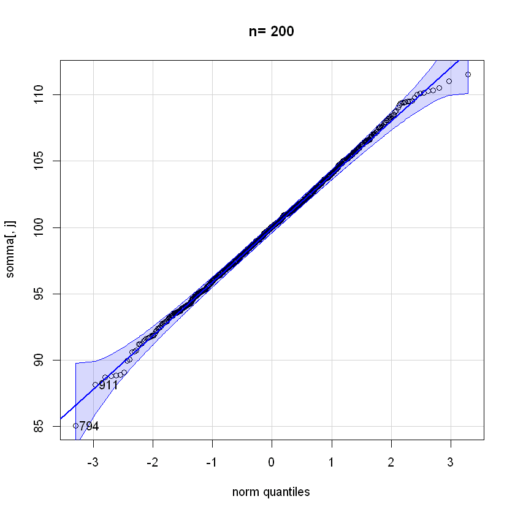

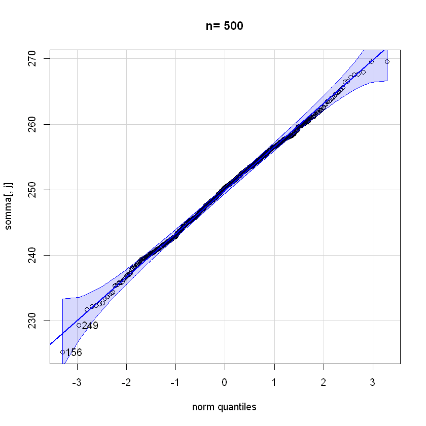

```r
# studiare guassianità con qqpot:

# de commenta se non hai il pacchetto installato
# install.packages("car")
library(car)
for(j in 1:length(n)){
    qqPlot(somma[,j],main=paste("n=",n[j]))
}
```